# Lab3

Shanpeng Li

## Introduction

The purpose of this lab is to show students how to apply non-parametric methods such as the Kaplan-Meier Product-Limit estimate and the Nelson-Aalen estimate.

First we will need to load the required packages. We will be using the following packages.

```r
library(survival)  # loading survival functions into R
library(KMsurv)    # datasets from Klein and Moeschberger textbook
```

## Kaplan-Meier (Product-Limit) Estimator (Section 4.2)

For survival data one commonly wants to find an estimate of the survival function $S(t)$. The standard estimator of $S(t)$ is the Kaplan-Meier estimator. Assuming $t_1 < t_2 < \ldots, t_D$ for $D$ distinct times, the Kaplan-Meier estimate is defined as follows,

$$\hat{S}(t) = \prod_{t_i \leq t} \left[1- \frac{d_i}{Y_i} \right],$$

where at $t_i$ there are $d_i$ events (deaths) and $Y_i$ number of individuals who are at risk at time $t_i$. To find the Kaplan-Meier estimates in `R`, we can use the `survfit( )` function from the `survival` library.

```r
data(drug6mp)
fit <- survfit(Surv(t2, relapse) ~ 1, data = drug6mp)
summary(fit) #Table 4.1a
```

```
## Call: survfit(formula = Surv(t2, relapse) ~ 1, data = drug6mp)
##
##  time n.risk n.event survival std.err lower 95% CI upper 95% CI
##     6     21       3    0.857  0.0764        0.720        1.000
##     7     17       1    0.807  0.0869        0.653        0.996
##    10     15       1    0.753  0.0963        0.586        0.968
##    13     12       1    0.690  0.1068        0.510        0.935
##    16     11       1    0.627  0.1141        0.439        0.896
##    22      7       1    0.538  0.1282        0.337        0.858
##    23      6       1    0.448  0.1346        0.249        0.807
```

### Graphical Presentations of the Product-Limit Estimates

Unlike SAS, R will not produce plots automatically. However, we can use the information stored in our `fit` variable. One common plot many report for survival data is the plot of the product-limit estimates. Another is the plot of $\hat{H}(t) = -\log(\hat{S(t)})$ vs. $t$. The commands are written below.

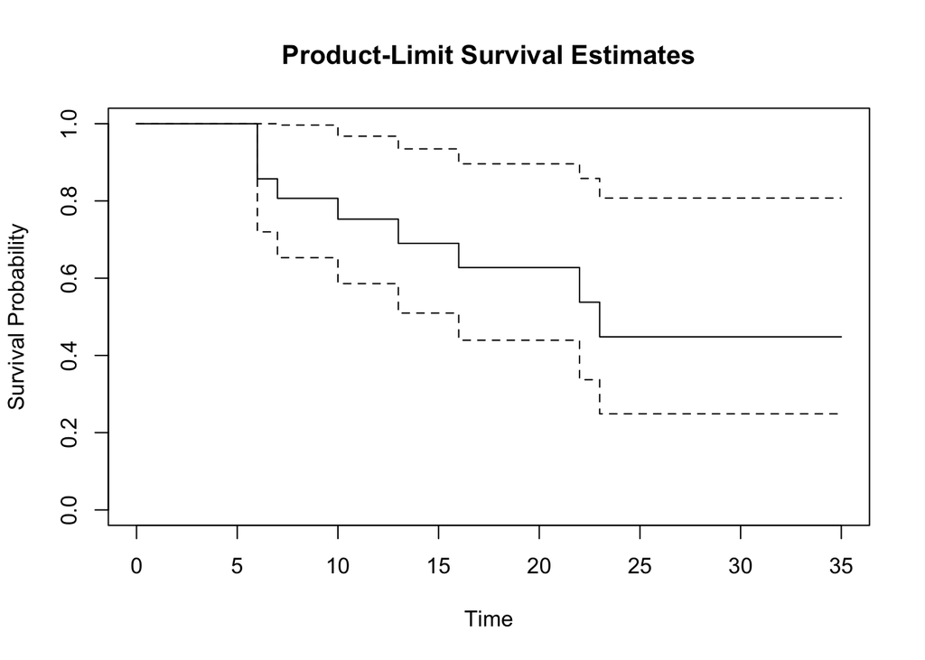

```r
# Plotting the Kaplan-Meier Estimates
plot(fit, main = 'Product-Limit Survival Estimates',
          ylab = 'Survival Probability', xlab = 'Time')
```

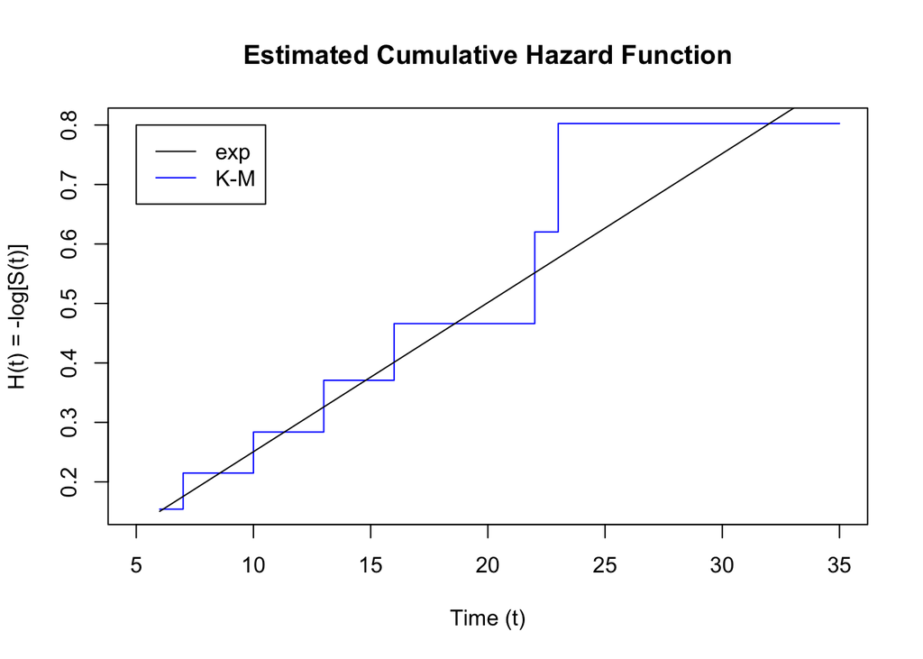

```r
# Plotting -log[S(t)] vs. t
plot(-log(fit$surv) ~ fit$time, type = 's', col = 'blue',
          main = 'Estimated Cumulative Hazard Function', ylab = 'H(t) = -log[S(t)]',
          xlab = 'Time (t)',
          xlim = c(5, 35))

##fit an exponential survival regression model
fit.exp <- survreg(Surv(drug6mp$t2, drug6mp$relapse) ~ 1, dist = "exponential")
lambdahat <- exp(-fit.exp$coefficients)
hazardhat <- fit$time * lambdahat

lines(fit$time, hazardhat, col = "black")
legend(5, 0.8, legend = c("exp", "K-M"), col = c("black", "blue"), lty = 1, cex = 1)
```

### Confidence Intervals (Section 4.3)

$(1-\alpha)\times100\%$ confidence intervals for the product-limit estimates can automatically be constructed through `survfit`. The arguments are `conf.type` for the type of interval to be constructed (default is `log`, but others include `log-log`, `plain` [linear], ``none`) and `conf.int` for the length of the interval (default is .95). (Note: The log option is `R` is different than the log-transformed intervals in Klein and Moeschberger, which corresponds to `conf.type = log-log`. )

## Nelson-Aalen Estimator

Recall the following relationship,
$$H(t) = - \log S(t).$$
Thus, we can estimate the cumulative hazard from the Kaplan-Meier estimate,
$$\hat{H}(t) = - \log \hat{S}(t).$$
We shall return to the `drug6mp` dataset for illustration.

```r
H.km <- -log(fit$surv); H.km
```

```
##  [1] 0.1541507 0.2147753 0.2147753 0.2837682 0.2837682 0.3707796 0.4660897
##  [8] 0.4660897 0.4660897 0.4660897 0.6202404 0.8025620 0.8025620 0.8025620
## [15] 0.8025620 0.8025620
```

An alternate method of estimating the cumulative hazard is through the Nelson-Aalen estimate,
$$\tilde{H}(t) = \sum_{t_i \leq t} \frac{d_i}{Y_i}.$$
Both $d_i$ and $Y_i$ can be extracted from `survfit`.

```r
#Nelson-Aalen Estimate of H(t):
h               <- fit$n.event/fit$n.risk
H.na            <- cumsum(h) #Nelson-Aalen estimates
s               <- fit$n.event/fit$n.risk^2
V.na            <- cumsum(s) #Variance estimate for the N-A estimator
NAest           <- cbind(H.na, sqrt(V.na))
colnames(NAest) <- c("NA-Est.","Std. Err")

#Table 4.2
NAest
```

```
##         NA-Est.   Std. Err
##  [1,] 0.1428571 0.08247861
##  [2,] 0.2016807 0.10130611
##  [3,] 0.2016807 0.10130611
##  [4,] 0.2683473 0.12127396
##  [5,] 0.2683473 0.12127396
##  [6,] 0.3516807 0.14714557
##  [7,] 0.4425898 0.17296323
##  [8,] 0.4425898 0.17296323
##  [9,] 0.4425898 0.17296323
## [10,] 0.4425898 0.17296323
## [11,] 0.5854469 0.22433110
## [12,] 0.7521136 0.27946775
## [13,] 0.7521136 0.27946775
## [14,] 0.7521136 0.27946775
## [15,] 0.7521136 0.27946775
## [16,] 0.7521136 0.27946775
```

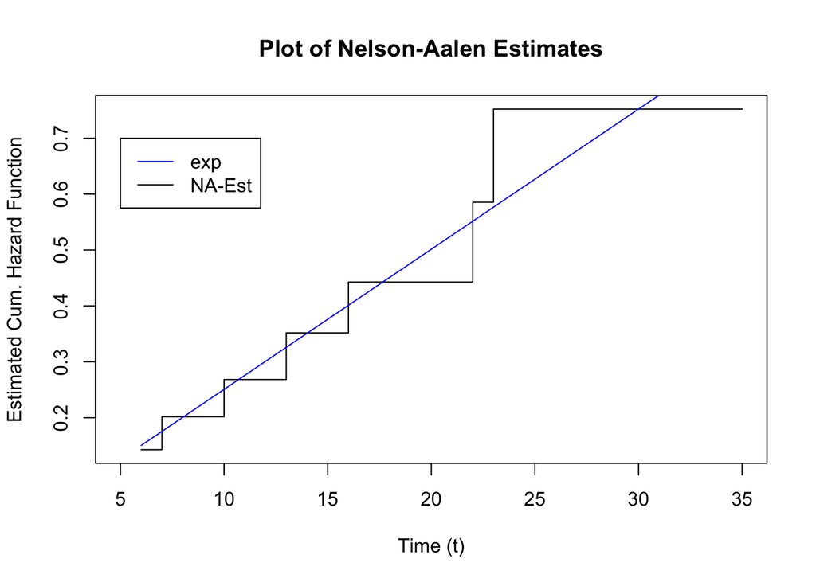

```r
#Plot of the Nelson-Aalen Estimate
plot(H.na ~ fit$time, type = 's',
     main="Plot of Nelson-Aalen Estimates", xlab="Time (t)",
     ylab="Estimated Cum. Hazard Function",
     xlim = c(5, 35))

lines(fit$time, hazardhat, col = "blue")
legend(5, 0.7, legend = c("exp", "NA-Est"), col = c("blue", "black"), lty = 1, cex = 1)
```

Below we will compare the estimates of the cumulative hazard function using both approaches.

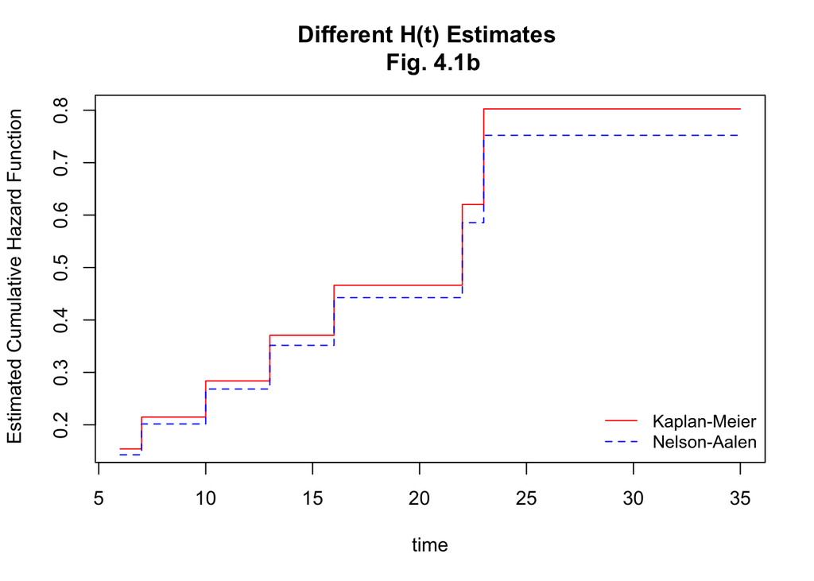

```r
#Comparing the Nelson-Aalen Estimate to the Kaplan-Meier Estimate
plot(H.km~fit$time, xlab = "time", ylab = " Estimated Cumulative Hazard Function",
     main = "Different H(t) Estimates \n Fig. 4.1b", type = "s", col = "red")
lines(H.na~fit$time, type = "s", lty = 2, col = "blue")
legend("bottomright", c("Kaplan-Meier", "Nelson-Aalen"), lty = 1:2,
     col = c("red", "blue"), bty = "n", cex = .9)
```

```r
data(bmt)
```

We shall focus on the *disease-free survival* probabilities for ALL, AML low risk and AML high risk patients. Looking at `help(bmt)`, we can see that the disease-free survival time and indicator are under `t2` and `d3` respectively. The `group` variable stores what group the patient is in. More detail about the dataset is in section 1.3.

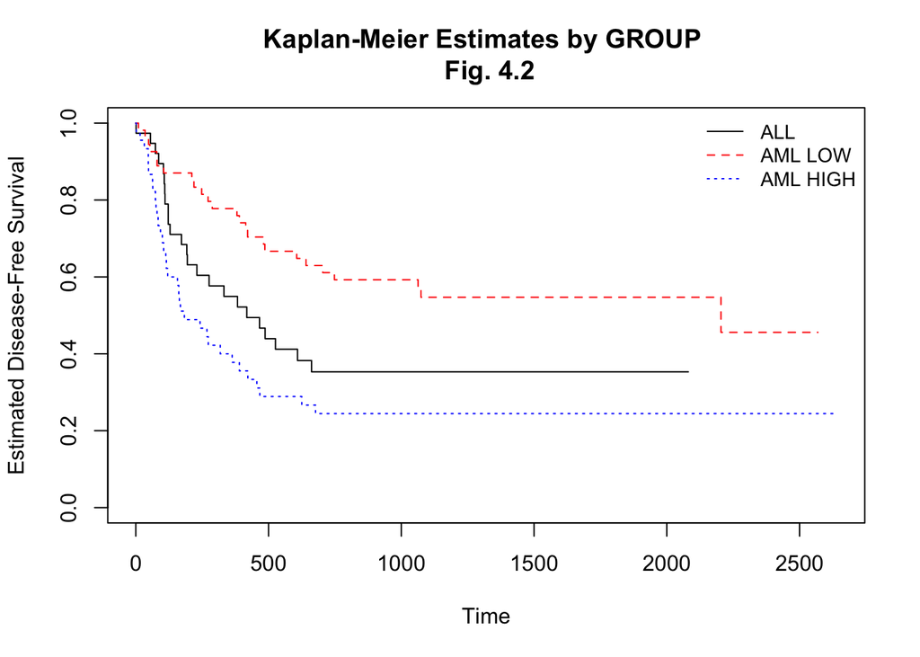

```r
fit.bmt <- survfit(Surv(t2, d3)~group, data = bmt)

plot(fit.bmt, col = c('black', 'red', 'blue'), lty = c(1, 2, 3), ylab = 'Estimated Disease-Free Survival', xlab = 'Time', main = 'Kaplan-Meier Estimates by GROUP \n Fig. 4.2')

legend("topright", c("ALL", "AML LOW", "AML HIGH"), lty = 1:3,
     col = c("black", "red", "blue"), bty = "n", cex = .9)
```

## Introduction

```r
#install.packages(survival)
#install.packages(KMsurv)
library(survival)  # loading survival functions into R
library(KMsurv)    # datasets from Klein and Moeschberger textbook
## type your own paths here
data_directory <- "functions/" #For later use
```

Some functions can be found at Eric Kawaguchi’s Github account: https://github.com/erickawaguchi/bios215.

Please have those functions ready and save them to your local machine.

## Arcsin Transformed Confidence Intervals

To the best of my knowlege, the `survfit` package does not include the arcsin transformed confidence intervals for the Kaplan-Meier estimate. An R function, `arcsin_ci.R` can be found on GitHub. We will compare the results to that of Table 4.4 in the book for the ALL group.

```r
source(paste0(data_directory, "arcsin_ci.R"))

data(bmt)
ci.fit <- survfit(Surv(bmt$t2[bmt$group == 1], bmt$d3[bmt$group == 1]) ~ 1)
res <- arcsin.ci(ci.fit, alpha = 0.05)
res
```

```
##    time  surv sigma lower upper
## 1     1 0.974 0.027 0.900 1.000
## 2    55 0.947 0.038 0.855 0.995
## 3    74 0.921 0.047 0.816 0.984
## 4    86 0.895 0.056 0.779 0.971
## 5   104 0.868 0.063 0.744 0.956
## 6   107 0.842 0.070 0.711 0.939
## 7   109 0.816 0.077 0.679 0.921
## 8   110 0.789 0.084 0.648 0.902
## 9   122 0.737 0.097 0.587 0.863
## 10  129 0.711 0.104 0.558 0.842
## 11  172 0.684 0.110 0.530 0.820
## 12  192 0.658 0.117 0.502 0.798
## 13  194 0.632 0.124 0.474 0.776
## 14  226 0.632 0.124 0.474 0.776
```

[output cut: 23 more lines]

Although confidence intervals for all survival estimates are found, we can see that the confidence intervals for $S(365)$ similar up to the third decimal.

## Bootstrapping Standard Errors (Not in book)

In class, we have learned that it is generally hard to find standard errors for quantiles such as the median. One way we can do this is by bootstrapping (Efron, 1979). For this part of the lab, we will show how one can bootstrap the standard errors for any quantile using a user-defined function.

First we will create a function to calculate the bootstrapped standard error. A function can be as simple (or as complicated), and as brief (or as elaborate) as one would want. Here, I tried to make a function that is a little more elaborate. You can make your own.

```r
source(paste0(data_directory, "quantile_boots.R"))
```

We will use the Example 7.9 on page 224. The data is not in `KMsurv` so manual entry in required :(

```r
t1 <- c(1, 63, 105, 129, 182, 216, 250, 262, 301, 301,
        342, 354, 356, 358, 380, 383, 383, 338, 394, 408, 460, 489,
        499, 523, 524, 535, 562, 569, 675, 676, 748, 778, 786, 797, 955, 968, 1000,
        1245, 1271, 1420, 1551, 1694, 2363, 2754, 2950)
t2 <- c(17, 42, 44, 48, 60, 72, 74, 95, 103, 108, 122, 144, 167, 170,
        183, 185, 193, 195, 197, 208, 234, 235, 254, 307, 315, 401, 445, 464, 484,
        528, 542, 547, 577, 580, 795, 855, 1366, 1577, 2060, 2412, 2486, 2796, 2802, 2934, 2988)

c1  <- c(rep(1, 43), 0, 0)
c2  <- c(rep(1, 39), rep(0, 6))

trt1 <- rep(1, 45)
trt2 <-  rep(2, 45)
```

Using `survival` we can get an estimate of the median, a corresponding standard error, and confidence interval.

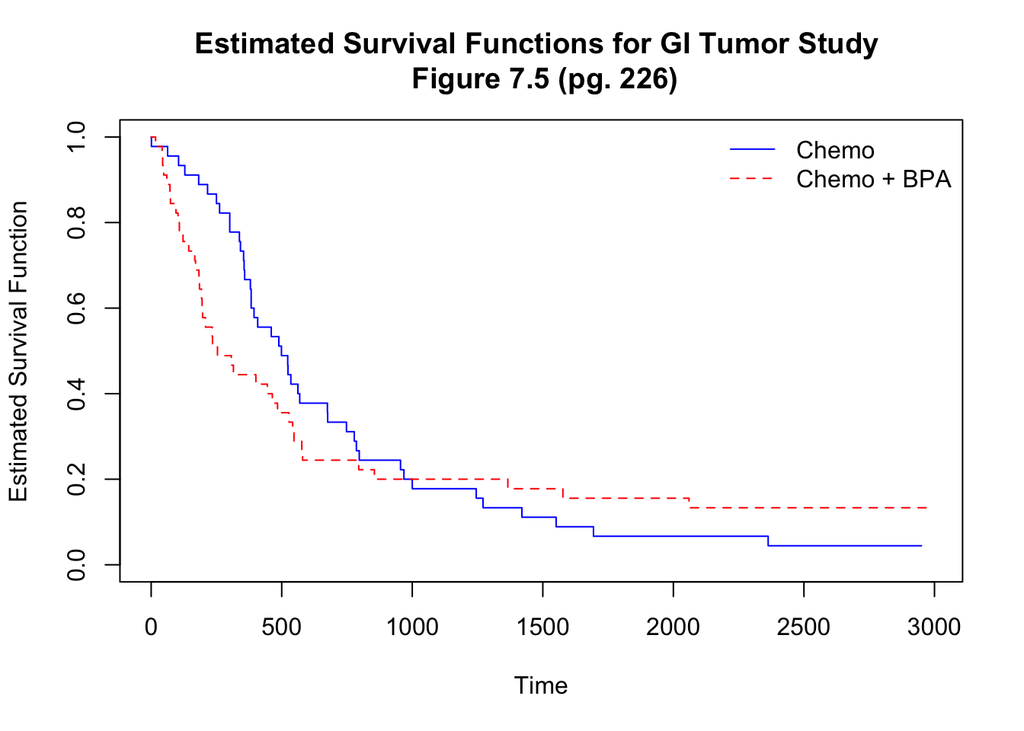

```r
fit <- survfit(Surv(c(t1, t2), c(c1, c2)) ~ c(trt1, trt2))

plot(fit, lty = c(1,2), col = c("blue", "red"),
     main = 'Estimated Survival Functions for GI Tumor Study \n Figure 7.5 (pg. 226)', ylab = 'Estimated Survival Function', xlab = 'Time')

legend('topright', c('Chemo', 'Chemo + BPA'), col = c('blue', 'red'), lty = 1:2, bty = 'n')
```

```r
fit
```

```
## Call: survfit(formula = Surv(c(t1, t2), c(c1, c2)) ~ c(trt1, trt2))
##
##                  n events median 0.95LCL 0.95UCL
## c(trt1, trt2)=1 45     43    499     383     748
## c(trt1, trt2)=2 45     39    254     193     542
```

Using our `quantile_boots` we can also get an estimate of the median (or any quantile), and a bootstrapped standard error.

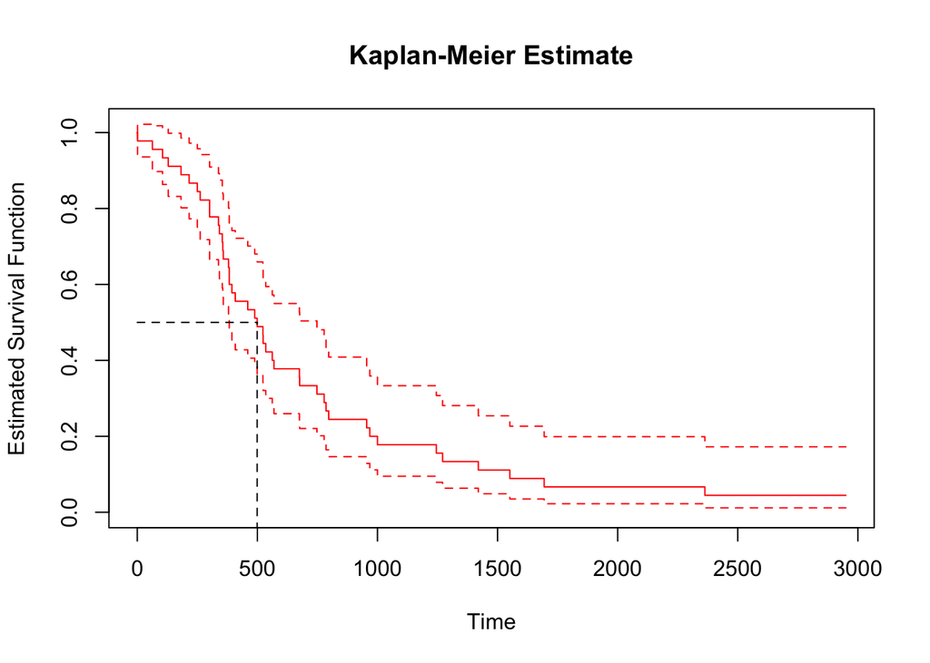

```
## $`Quantile Estimate`
## [1] 499
##
## $`Std. Err`
## [1] 73.4252
```

```r
quantile_boots(t1, c1, 0.5, R = 1000, plots = T)
```

```r
#quantile_boots(t2, c2, R = 1000)
```

## estimate S(t) and its standard error using bootstrap method

```r
source(paste0(data_directory, "SurvivalProb_boots.R"))
```

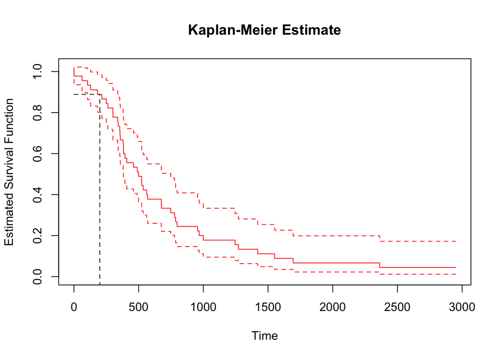

```
## $Time
## [1] 200
##
## $`Survival Probability Estimate`
## [1] 0.8888889
##
## $`Std. Err`
## [1] 0.04727329
```

```r
SurvivalProb_boots(t1, c1, 200, plots = TRUE)
```

**Question**: Sometimes the bootstrap will fail or give large standard errors. Why?

## Likelihood Ratio Confidence Intervals

As disucssed in class one may use a likelihood ratio type confidence interval. To generate such confidence intervals one will use the `LRci` function on GitHub. A `survfit` function is required as well as the time, `t`, of interest. A root finder is used to find the upper and lower limits of the confidence interval. Since the upper root is searched within the interval $(0, \infty)$, we set the upper limit to be an arbitrarily high number, 100. However, the root may not lie in this interval and a warning will appear. In such cases, one may change the `upper.lim` value and run the function again.

Using the ALL group for the `bmt` dataset and being interested in $S(365)$ we will try to find a $95\%$ confidence interval using the likelihood ratio approach.

```r
source(paste0(data_directory, "LRci.R"))

my.surv <- survfit(Surv(bmt$t2[bmt$group==1], bmt$d3[bmt$group==1])~1, conf.type = 'none')

LRci.surv(my.surv, t = 365)
```

```
## $time
## [1] 365
##
## $surv.est
## [1] 0.549
##
## $conf.int
##         LL    UL
## [1,] 0.391 0.701
##
## $alpha
## [1] 0.05
```

When compared to Table 4.4, this confidence interval is similar to all three large sample theory approaches.

## Interval Estimation for Median Survival Time (Section 4.5)

To find a $95\%$ confidence interval for the median survival time, we can use the method developed by Brookmeyer and Crowley (1982). The code is on GitHub under `bc_median_ci` and includes approaches for linear, log-transformed, and arcsine-transformed confidence intervals.

```r
source(paste0(data_directory, "bc_median_ci.R"))

bc.median.ci(my.surv, table = TRUE)
```

```
## $median
## [1] 418
##
## $lower
## [1] 194
##
## $upper
## [1] NA
##
## $type
## [1] "linear"
##
## $alpha
## [1] 0.05
##
```

[output cut: 25 more lines]

We can see that these results are similar to that of Table 4.7. If you do not want to include the table you can set `table = FALSE` in the function.

## Interval Estimation for Mean Survival Time (Section 4.5)

A natural estimator for $\mu$ is given by
$$\hat{\mu} = \int_0^\infty \hat{S}(t) dt.$$
However this expression is only appropriate if the largest observed survival time is uncensored. Otherwise, the Kaplan-Meier estimator is not defined beyond the largest uncensored survival time. A common solution is to estimated the resticted mean survival within some preassigned interval $[0, \tau]$ for some $\tau \leq t_{max}$, the largest observed survival time. Therefore,
$$\hat{\mu}_{\tau} = \int_0^\tau \hat{S}(t),$$

and the variance of this estimator is defined as
$$Var[\hat{\mu}_{\tau}] = \sum_{i = 1}^D \left[\int_{t_i}^\tau \hat{S}(t)\right]^2 \frac{d_i}{r_i(r_i - d_i)}.$$

In `R` one may use the `print` function to find the restricted mean survival time given a prespecified time `t0`. The following is code to get the restricted mean survival time and its corresponding standard error for Example 4.2

```r
data(bmt)

fit.ALL <- survfit(Surv(bmt$t2[bmt$group == 1], bmt$d3[bmt$group == 1]) ~ 1, conf.type = 'none')

fit.low <- survfit(Surv(bmt$t2[bmt$group == 2], bmt$d3[bmt$group == 2]) ~ 1, conf.type = 'none')

fit.high <- survfit(Surv(bmt$t2[bmt$group == 3], bmt$d3[bmt$group == 3]) ~ 1, conf.type = 'none')

t0 <- 2081 #Looking at restricted mean from [0, 2081]

print(fit.ALL, print.rmean = TRUE, rmean = t0) #ALL
```

```
## Call: survfit(formula = Surv(bmt$t2[bmt$group == 1], bmt$d3[bmt$group ==
##     1]) ~ 1, conf.type = "none")
##
##          n     events     *rmean *se(rmean)     median
##         38         24        899        146        418
##     * restricted mean with upper limit =  2081
```

```r
print(fit.low, print.rmean = TRUE, rmean = t0) #Low
```

```
## Call: survfit(formula = Surv(bmt$t2[bmt$group == 2], bmt$d3[bmt$group ==
##     2]) ~ 1, conf.type = "none")
##
##          n     events     *rmean *se(rmean)     median
##         54         25       1315        119       2204
##     * restricted mean with upper limit =  2081
```

```r
print(fit.high, print.rmean = TRUE, rmean = t0) #High
```

```
## Call: survfit(formula = Surv(bmt$t2[bmt$group == 3], bmt$d3[bmt$group ==
##     3]) ~ 1, conf.type = "none")
##
##          n     events     *rmean *se(rmean)     median
##         45         34        656        123        183
##     * restricted mean with upper limit =  2081
```